**GitHub Repository:** https://github.com/sadieakel/GSB-544/tree/master/Labs/Lab_7

# Lab 7

## Importing the Dataset and Loading Necessary Libraries

```python
import matplotlib.pyplot as plt
import pandas as pd
import numpy as np
from sklearn.pipeline import Pipeline
from sklearn.preprocessing import StandardScaler, OneHotEncoder, PolynomialFeatures
from sklearn.linear_model import LinearRegression, Ridge, Lasso, ElasticNet, LogisticRegression
from sklearn.model_selection import train_test_split, cross_val_score, cross_val_predict
from sklearn.metrics import r2_score, confusion_matrix, accuracy_score, precision_recall_fscore_support, roc_auc_score, ConfusionMatrixDisplay, RocCurveDisplay, recall_score, precision_score, make_scorer, cohen_kappa_score
from sklearn.pipeline import Pipeline
from sklearn.compose import make_column_selector, ColumnTransformer
from sklearn.model_selection import GridSearchCV
import matplotlib.pyplot as plt
from palmerpenguins import load_penguins
from sklearn.neighbors import KNeighborsRegressor, KNeighborsClassifier
from sklearn.tree import DecisionTreeRegressor, DecisionTreeClassifier
```

```python
ha = pd.read_csv("https://www.dropbox.com/s/aohbr6yb9ifmc8w/heart_attack.csv?dl=1")
```

```python
ha=ha.dropna()
```

```python
ha.info()
```

```
<class 'pandas.core.frame.DataFrame'>
RangeIndex: 273 entries, 0 to 272
Data columns (total 8 columns):
 #   Column   Non-Null Count  Dtype
---  ------   --------------  -----
 0   age      273 non-null    int64
 1   sex      273 non-null    int64
 2   cp       273 non-null    int64
 3   trtbps   273 non-null    int64
 4   chol     273 non-null    int64
 5   restecg  273 non-null    int64
 6   thalach  273 non-null    int64
 7   output   273 non-null    int64
dtypes: int64(8)
memory usage: 17.2 KB
```

Note that all variables (even categorical variables) are considered integers in this dataset. We must change these variables into categorical objects so we can later dummify them.

```python
ha["sex"]=ha["sex"].astype("str")
ha["cp"]=ha["cp"].astype("str")
ha["restecg"]=ha["restecg"].astype("str")
```

```python
ha.info()
```

```
<class 'pandas.core.frame.DataFrame'>
RangeIndex: 273 entries, 0 to 272
Data columns (total 8 columns):
 #   Column   Non-Null Count  Dtype
---  ------   --------------  -----
 0   age      273 non-null    int64
 1   sex      273 non-null    object
 2   cp       273 non-null    object
 3   trtbps   273 non-null    int64
 4   chol     273 non-null    int64
 5   restecg  273 non-null    object
 6   thalach  273 non-null    int64
 7   output   273 non-null    int64
dtypes: int64(5), object(3)
memory usage: 17.2+ KB
```

```python
ha["cp"].unique()
```

```
array(['3', '2', '1', '0'], dtype=object)
```

This has been fixed! Now, we can proceed to analysis of our dataset.

## Part 1: Fitting Models

We will use different types of models to try and classify patients based on characteristics into categories of either at risk for a heart attack, or not at risk of a heart attack.

Initial Column Transformers and X and y:

```python
y=ha["output"]
X=ha.drop(columns="output")
```

```python
ct = ColumnTransformer(
  [
    ("dummify", OneHotEncoder(sparse_output = False, handle_unknown='ignore'), make_column_selector(dtype_include=object)),
    ("standardize", StandardScaler(), make_column_selector(dtype_include=np.number))
  ],
  remainder = "drop"
).set_output(transform = "pandas")
```

### Q1: KNN

Trying the full model:

```python
knn_pipeline=Pipeline([
    ("preprocessing", ct),
    ("knn", KNeighborsClassifier())
])

knn_pipeline.fit(X,y)
```

```
Pipeline(steps=[('preprocessing',
                 ColumnTransformer(transformers=[('dummify',
                                                  OneHotEncoder(handle_unknown='ignore',
                                                                sparse_output=False),
                                                  <sklearn.compose._column_transformer.make_column_selector object at 0x14ef1c710>),
                                                 ('standardize',
                                                  StandardScaler(),
                                                  <sklearn.compose._column_transformer.make_column_selector object at 0x14ef1cd70>)])),
                ('knn', KNeighborsClassifier())])
```

Now, we tune the k value:

```python
k_value = {'knn__n_neighbors': (5, 10, 20, 30, 40, 45, 50, 55, 60, 70, 80, 90, 100)}

gscvknn = GridSearchCV(knn_pipeline, k_value, cv = 5, scoring='roc_auc')
gscvknn_fitted = gscvknn.fit(X, y)
print(gscvknn_fitted.best_score_, gscvknn_fitted.best_params_)
```

```
0.8222514588859416 {'knn__n_neighbors': 50}
```

The ROC-AUC value is highest when the the k value is 50, where for this model we recieve a ROC-AUC value of 0.822.

Trying other models:

First, we try a model that removes sex from the model.

```python
y_reduced_knn=ha["output"]
X_reduced_knn=ha.drop(columns=["output", "sex"])
```

```python
knn_reduced_pipeline=Pipeline([
    ("preprocessing", ct),
    ("knn", KNeighborsClassifier())
])

knn_reduced_pipeline.fit(X_reduced_knn,y_reduced_knn)
```

```
Pipeline(steps=[('preprocessing',
                 ColumnTransformer(transformers=[('dummify',
                                                  OneHotEncoder(handle_unknown='ignore',
                                                                sparse_output=False),
                                                  <sklearn.compose._column_transformer.make_column_selector object at 0x14ef1c710>),
                                                 ('standardize',
                                                  StandardScaler(),
                                                  <sklearn.compose._column_transformer.make_column_selector object at 0x14ef1cd70>)])),
                ('knn', KNeighborsClassifier())])
```

```python
k_value = {'knn__n_neighbors': (5, 10, 20, 30, 40, 45, 50, 55, 60, 70, 80, 90, 100)}

gscvknn2 = GridSearchCV(knn_reduced_pipeline, k_value, cv = 5, scoring='roc_auc')
gscvknn2_fitted = gscvknn2.fit(X_reduced_knn, y_reduced_knn)
print(gscvknn2_fitted.best_score_, gscvknn2_fitted.best_params_)
```

```
0.789342528735632 {'knn__n_neighbors': 55}
```

The ROC-AUC value is highest when the the k value is 55, where for this model we recieve a ROC-AUC value of 0.789. So far, our first model out performs this model.

Now, we will proceed to try a model including an interaction effect between cholesterol and resting electrocardiographic results:

```python
ct_int = ColumnTransformer(
    [
        ("interaction0", PolynomialFeatures(interaction_only=True), ["standardize__chol", "dummify__restecg_0"]),
        ("interaction1", PolynomialFeatures(interaction_only=True), ["standardize__chol", "dummify__restecg_1"])
    ],
  remainder = "passthrough"
).set_output(transform = "pandas")
```

```python
knn_int_pipeline=Pipeline([
    ("preprocessing", ct),
    ("interaction", ct_int),
    ("knn", KNeighborsClassifier())
])

knn_int_pipeline.fit(X,y)
```

```
Pipeline(steps=[('preprocessing',
                 ColumnTransformer(transformers=[('dummify',
                                                  OneHotEncoder(handle_unknown='ignore',
                                                                sparse_output=False),
                                                  <sklearn.compose._column_transformer.make_column_selector object at 0x14ef1c710>),
                                                 ('standardize',
                                                  StandardScaler(),
                                                  <sklearn.compose._column_transformer.make_column_selector object at 0x14ef1cd70>)])),
                ('interaction',
                 ColumnTransformer(remainder='passthrough',
                                   transformers=[('interaction0',
                                                  PolynomialFeatures(interaction_only=True),
                                                  ['standardize__chol',
                                                   'dummify__restecg_0']),
                                                 ('interaction1',
                                                  PolynomialFeatures(interaction_only=True),
                                                  ['standardize__chol',
                                                   'dummify__restecg_1'])])),
                ('knn', KNeighborsClassifier())])
```

```python
k_value = {'knn__n_neighbors': (5, 10, 20, 30, 40, 45, 50, 55, 60, 70, 80, 90, 100)}

gscvknn3 = GridSearchCV(knn_int_pipeline, k_value, cv = 5, scoring='roc_auc')
gscvknn3_fitted = gscvknn3.fit(X, y)
print(gscvknn3_fitted.best_score_, gscvknn3_fitted.best_params_)
```

```
0.8126687886825819 {'knn__n_neighbors': 50}
```

The best model based on the ROC-AUC value is the first model we tried (containing all predictors and no interaction term), with a k value of 50. We will now fit this complete model:

```python
knn_pipeline_best=Pipeline([
    ("preprocessing", ct),
    ("knn", KNeighborsClassifier(n_neighbors=50))
])

knn_pipeline_best.fit(X,y)
```

```
Pipeline(steps=[('preprocessing',
                 ColumnTransformer(transformers=[('dummify',
                                                  OneHotEncoder(handle_unknown='ignore',
                                                                sparse_output=False),
                                                  <sklearn.compose._column_transformer.make_column_selector object at 0x14ef1c710>),
                                                 ('standardize',
                                                  StandardScaler(),
                                                  <sklearn.compose._column_transformer.make_column_selector object at 0x14ef1cd70>)])),
                ('knn', KNeighborsClassifier(n_neighbors=50))])
```

Cross-validated ROC-AUC score:

```python
scores_knn_best = cross_val_score(knn_pipeline_best, X, y, cv=5, scoring='roc_auc')
print(scores_knn_best.mean())
```

```
0.8222514588859416
```

The cross-validated ROC-AUC score is 0.8222514588859416.

Confusion matrix for this model:

```
[[ 99  28]
 [ 45 101]]
```

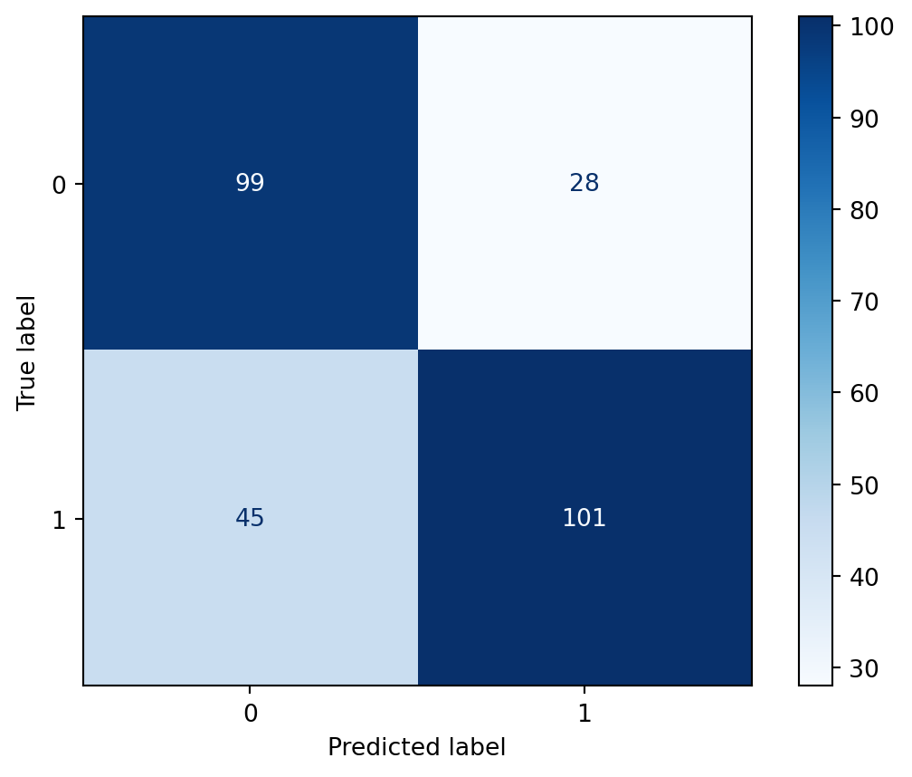

```python
y_pred_cv = cross_val_predict(knn_pipeline_best, X, y, cv=5)
cm = confusion_matrix(y, y_pred_cv)
disp = ConfusionMatrixDisplay(confusion_matrix=cm) #used google/chat gpt for the ConfusionMatrixDisplay
disp.plot(cmap="Blues")
print(cm)
```

This confusion matrix showed that, with this best KNN model, in our cross validated predictions we got 101 true positives (we predicted at risk of heart attack and subject was truly at risk of hear attack), 99 true negatives (we predicted no risk of heart attack and subject was not at risk of heart attack). We, however, predicted that 28 subjects were at risk of a heart attach when they were not (false positives) and predicted that 45 subjects were not at risk of a heart attack when they were at risk of a heart attack (false negatives).

### Q2: Logistic Regression

```python
logistic_regression_pipeline=Pipeline(
    [("preprocessing", ct),
    ("logistic regression", LogisticRegression())]
)
logistic_regression_pipeline.fit(X,y)
```

```
Pipeline(steps=[('preprocessing',
                 ColumnTransformer(transformers=[('dummify',
                                                  OneHotEncoder(handle_unknown='ignore',
                                                                sparse_output=False),
                                                  <sklearn.compose._column_transformer.make_column_selector object at 0x14ef1c710>),
                                                 ('standardize',
                                                  StandardScaler(),
                                                  <sklearn.compose._column_transformer.make_column_selector object at 0x14ef1cd70>)])),
                ('logistic regression', LogisticRegression())])
```

```python
params = {
    'logistic regression__penalty': ['l1', 'l2', 'elasticnet', None],
    'logistic regression__C': [0.001, 0.01, 0.1, 1, 10, 100]
}

gscvlogistic = GridSearchCV(logistic_regression_pipeline, params, cv = 5, scoring='roc_auc')
gscvlogistic_fitted = gscvlogistic.fit(X, y)
print(gscvlogistic_fitted.best_score_, gscvlogistic_fitted.best_params_)
```

```
0.864367816091954 {'logistic regression__C': 1, 'logistic regression__penalty': 'l2'}
```

Now, we will try to eliminate some predictors from our model to see if we get a better ROC-AUC value from a simpler model and prevent overfitting.

```python
X_reduced_logistic=ha.drop(columns=["output", "age"])

logistic_regression_pipeline_reduced=Pipeline(
    [("preprocessing", ct),
    ("logistic regression", LogisticRegression())]
)
logistic_regression_pipeline_reduced.fit(X_reduced_logistic,y)


params = {
    'logistic regression__penalty': ['l1', 'l2', 'elasticnet', None],
    'logistic regression__C': [0.001, 0.01, 0.1, 1, 10, 100]
}

gscvlogistic_reduced = GridSearchCV(logistic_regression_pipeline_reduced, params, cv = 5, scoring='roc_auc')
gscvlogistic_reduced_fitted = gscvlogistic_reduced.fit(X_reduced_logistic, y)
print(gscvlogistic_reduced_fitted.best_score_, gscvlogistic_reduced_fitted.best_params_)
```

```
0.8690058355437665 {'logistic regression__C': 1, 'logistic regression__penalty': 'l2'}
```

Now, we can try a model that includes an interaction effect!

```python
ct_int_logistic = ColumnTransformer(
    [
        ("interaction0", PolynomialFeatures(interaction_only=True), ["standardize__thalach", "dummify__cp_0"]),
        ("interaction1", PolynomialFeatures(interaction_only=True), ["standardize__thalach", "dummify__cp_1"]),
        ("interaction2", PolynomialFeatures(interaction_only=True), ["standardize__thalach", "dummify__cp_2"])
    ],
  remainder = "passthrough"
).set_output(transform = "pandas")
```

```python
logistic_regression_int_pipeline=Pipeline(
    [("preprocessing", ct),
    ("interaction", ct_int_logistic),
    ("logistic regression", LogisticRegression())]
)
logistic_regression_int_pipeline.fit(X,y)
```

```
Pipeline(steps=[('preprocessing',
                 ColumnTransformer(transformers=[('dummify',
                                                  OneHotEncoder(handle_unknown='ignore',
                                                                sparse_output=False),
                                                  <sklearn.compose._column_transformer.make_column_selector object at 0x14ef1c710>),
                                                 ('standardize',
                                                  StandardScaler(),
                                                  <sklearn.compose._column_transformer.make_column_selector object at 0x14ef1cd70>)])),
                ('interaction',
                 ColumnT...
                                   transformers=[('interaction0',
                                                  PolynomialFeatures(interaction_only=True),
                                                  ['standardize__thalach',
                                                   'dummify__cp_0']),
                                                 ('interaction1',
                                                  PolynomialFeatures(interaction_only=True),
                                                  ['standardize__thalach',
                                                   'dummify__cp_1']),
                                                 ('interaction2',
                                                  PolynomialFeatures(interaction_only=True),
                                                  ['standardize__thalach',
                                                   'dummify__cp_2'])])),
                ('logistic regression', LogisticRegression())])
```

```python
params = {
    'logistic regression__penalty': ['l1', 'l2', 'elasticnet', None],
    'logistic regression__C': [0.001, 0.01, 0.1, 1, 10, 100]
}

gscvlogistic_int = GridSearchCV(logistic_regression_int_pipeline, params, cv = 5, scoring='roc_auc')
gscvlogistic_int_fitted = gscvlogistic_int.fit(X, y)
print(gscvlogistic_int_fitted.best_score_, gscvlogistic_int_fitted.best_params_)
```

```
0.8586779840848807 {'logistic regression__C': 1, 'logistic regression__penalty': 'l2'}
```

Now, we can fit this optimal model to all our data:

```python
ct_reduced_logistic = ColumnTransformer(
  [
    ("dummify", OneHotEncoder(sparse_output = False, handle_unknown='ignore'), ["cp", "restecg", "sex"]),
    ("standardize", StandardScaler(), ["trtbps", "chol", "thalach"])
  ],
  remainder = "drop"
).set_output(transform = "pandas")
```

```python
logisitic_pipeline_best=Pipeline([
    ("preprocessing", ct_reduced_logistic),
    ("logistic regression", LogisticRegression(penalty='l2', C=1))
])

logisitic_pipeline_best.fit(X,y)
```

```
Pipeline(steps=[('preprocessing',
                 ColumnTransformer(transformers=[('dummify',
                                                  OneHotEncoder(handle_unknown='ignore',
                                                                sparse_output=False),
                                                  ['cp', 'restecg', 'sex']),
                                                 ('standardize',
                                                  StandardScaler(),
                                                  ['trtbps', 'chol',
                                                   'thalach'])])),
                ('logistic regression', LogisticRegression(C=1))])
```

```python
scores_logistic_best = cross_val_score(logisitic_pipeline_best, X, y, cv=5, scoring='roc_auc')
print(scores_logistic_best.mean())
```

```
0.8690058355437665
```

The cross-validated ROC-AUC score is 0.869.

```
[[ 95  32]
 [ 30 116]]
```

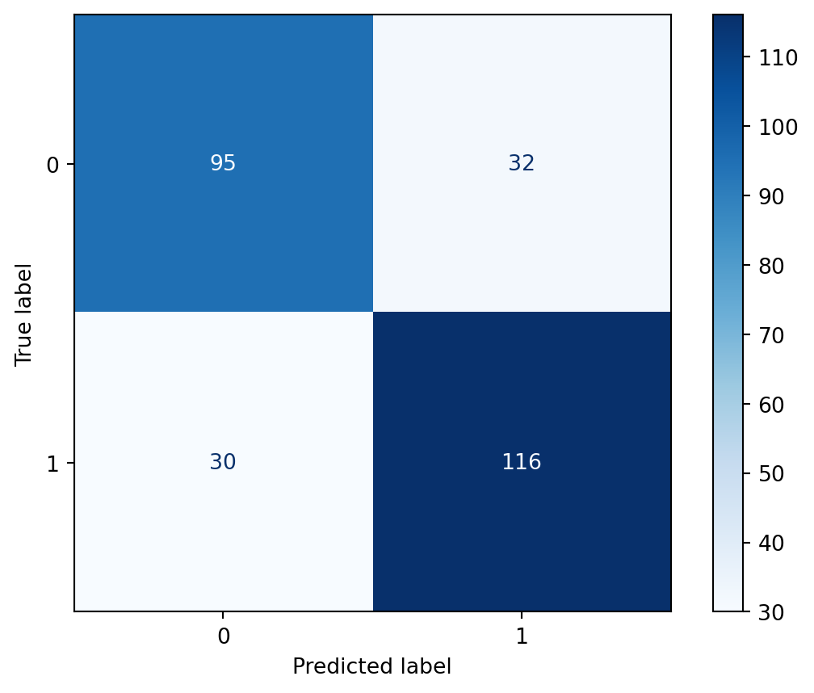

```python
y_pred_cv_logistic = cross_val_predict(logisitic_pipeline_best, X, y, cv=5)
cm3 = confusion_matrix(y, y_pred_cv_logistic)
disp = ConfusionMatrixDisplay(confusion_matrix=cm3) #used google/chat gpt for the ConfusionMatrixDisplay
disp.plot(cmap="Blues")
print(cm3)
```

This confusion matrix showed that, with this best logistic regression model, in our cross validated predictions we got 116 true positives (we predicted at risk of heart attack and subject was truly at risk of hear attack), 95 true negatives (we predicted no risk of heart attack and subject was not at risk of heart attack). We, however, predicted that 32 subjects were at risk of a heart attach when they were not (false positives) and predicted that 30 subjects were not at risk of a heart attack when they were at risk of a heart attack (false negatives).

### Q3: Decision Tree

Trying the full model:

```python
tree_pipeline=Pipeline([
    ("preprocessing", ct),
    ("decision tree", DecisionTreeClassifier())
])

tree_pipeline.fit(X,y)
```

```
Pipeline(steps=[('preprocessing',
                 ColumnTransformer(transformers=[('dummify',
                                                  OneHotEncoder(handle_unknown='ignore',
                                                                sparse_output=False),
                                                  <sklearn.compose._column_transformer.make_column_selector object at 0x14ef1c710>),
                                                 ('standardize',
                                                  StandardScaler(),
                                                  <sklearn.compose._column_transformer.make_column_selector object at 0x14ef1cd70>)])),
                ('decision tree', DecisionTreeClassifier())])
```

Now, we tune the alpha value:

```python
alphas = {'decision tree__ccp_alpha': (0.0001, 0.001, 0.01, 0.05, 0.075, 0.09, 0.1, 0.11, 1, 10, 50, 100)}
gscvtree= GridSearchCV(tree_pipeline, alphas, cv = 5, scoring='roc_auc')
gscvtree_fitted = gscvtree.fit(X, y)
```

```python
print(gscvtree_fitted.best_score_, gscvtree_fitted.best_params_)
```

```
0.7533333333333332 {'decision tree__ccp_alpha': 0.05}
```

The best ROC-AUC score of this model is 0.7533 and is reached when alpha=0.05

Now, we will try a model that includes an interaction effect between maximum heart rate achieved during exercise and chest pain type, since certain heart rate levels may cause different types of chest pain:

```python
ct_int = ColumnTransformer(
    [
        ("interaction0", PolynomialFeatures(interaction_only=True), ["standardize__thalach", "dummify__cp_0"]),
        ("interaction1", PolynomialFeatures(interaction_only=True), ["standardize__thalach", "dummify__cp_1"]),
        ("interaction2", PolynomialFeatures(interaction_only=True), ["standardize__thalach", "dummify__cp_2"]),
    ],
  remainder = "passthrough"
).set_output(transform = "pandas")
```

```python
tree_int_pipeline=Pipeline([
    ("preprocessing", ct),
    ("interaction", ct_int),
    ("decision tree", DecisionTreeClassifier())
])

tree_int_pipeline.fit(X,y)
```

```
Pipeline(steps=[('preprocessing',
                 ColumnTransformer(transformers=[('dummify',
                                                  OneHotEncoder(handle_unknown='ignore',
                                                                sparse_output=False),
                                                  <sklearn.compose._column_transformer.make_column_selector object at 0x14ef1c710>),
                                                 ('standardize',
                                                  StandardScaler(),
                                                  <sklearn.compose._column_transformer.make_column_selector object at 0x14ef1cd70>)])),
                ('interaction',
                 ColumnT...
                                   transformers=[('interaction0',
                                                  PolynomialFeatures(interaction_only=True),
                                                  ['standardize__thalach',
                                                   'dummify__cp_0']),
                                                 ('interaction1',
                                                  PolynomialFeatures(interaction_only=True),
                                                  ['standardize__thalach',
                                                   'dummify__cp_1']),
                                                 ('interaction2',
                                                  PolynomialFeatures(interaction_only=True),
                                                  ['standardize__thalach',
                                                   'dummify__cp_2'])])),
                ('decision tree', DecisionTreeClassifier())])
```

```python
alphas = {'decision tree__ccp_alpha': (0.0001, 0.001, 0.01, 0.05, 0.075, 0.09, 0.1, 0.11, 1, 10, 50, 100)}
gscv2tree= GridSearchCV(tree_int_pipeline, alphas, cv = 5, scoring='roc_auc')
gscv2tree_fitted = gscv2tree.fit(X, y)
```

```python
print(gscv2tree_fitted.best_score_, gscv2tree_fitted.best_params_)
```

```
0.7533333333333332 {'decision tree__ccp_alpha': 0.05}
```

The best ROC-AUC score of this model is 0.7533 and is reached when alpha=0.05. This is the same as the previous model, and since the previous model is simpler we will proceed with that model.

Since adding an interaction effect did not help the ROC-AUC values for this model, we will now try reducing our model.

```python
X_reduced_tree=ha.drop(columns=["output", "sex", "chol", "trtbps"])
```

Now, we tune the alpha value:

```python
alphas = {'decision tree__ccp_alpha': (0.0001, 0.001, 0.01, 0.05, 0.075, 0.09, 0.1, 0.11, 1, 10, 50, 100)}
gscv3tree= GridSearchCV(tree_pipeline, alphas, cv = 5, scoring='roc_auc')
gscv3tree_fitted = gscvtree.fit(X_reduced_tree, y)
```

```python
print(gscv3tree_fitted.best_score_, gscv3tree_fitted.best_params_)
```

```
0.7739593280282936 {'decision tree__ccp_alpha': 0.01}
```

Many different reductions were tried, and different variables were edited to see which performed better than the original model. Noteably a model with the excluded variables and age also performed better than the original model (but worse than the model with the 3 excluded predicted variables)

```python
ct_reduced = ColumnTransformer(
  [
    ("dummify", OneHotEncoder(sparse_output = False, handle_unknown='ignore'), ["cp", "restecg"]),
    ("standardize", StandardScaler(), ["age", "thalach"])
  ],
  remainder = "drop"
).set_output(transform = "pandas")
```

```python
tree_pipeline_best=Pipeline([
    ("preprocessing", ct_reduced),
    ("decision tree", DecisionTreeClassifier(ccp_alpha=0.01))
])

tree_pipeline_best.fit(X,y)
```

```
Pipeline(steps=[('preprocessing',
                 ColumnTransformer(transformers=[('dummify',
                                                  OneHotEncoder(handle_unknown='ignore',
                                                                sparse_output=False),
                                                  ['cp', 'restecg']),
                                                 ('standardize',
                                                  StandardScaler(),
                                                  ['age', 'thalach'])])),
                ('decision tree', DecisionTreeClassifier(ccp_alpha=0.01))])
```

```python
scores_tree_best = cross_val_score(tree_pipeline_best, X, y, cv=5, scoring='roc_auc')
print(scores_tree_best.mean())
```

```
0.7774076038903625
```

The cross-validated ROC-AUC score is 0.7774076038903625.

Confusion matrix for this model:

```
[[ 88  39]
 [ 32 114]]
```

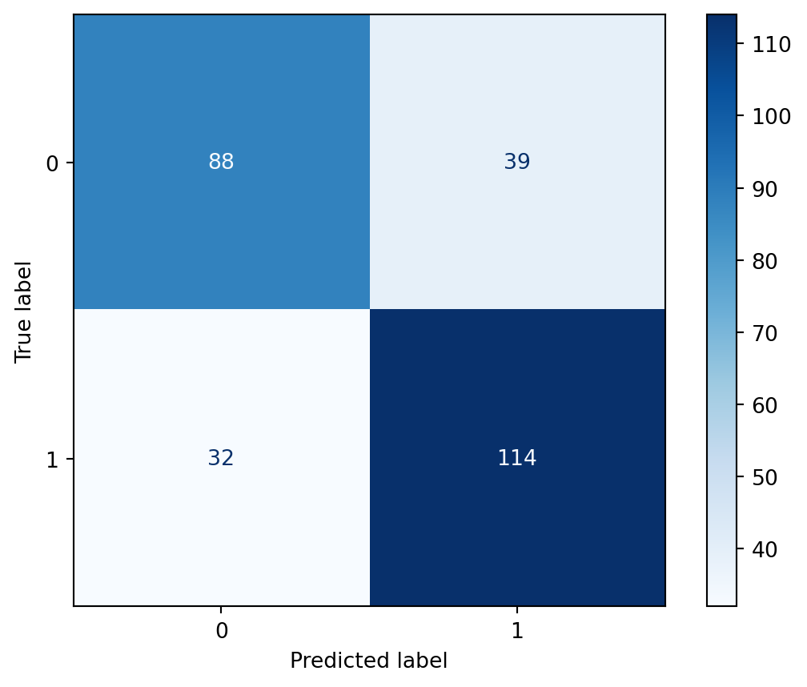

```python
y_pred_cv_tree = cross_val_predict(tree_pipeline_best, X, y, cv=5)
cm2 = confusion_matrix(y, y_pred_cv_tree)
disp = ConfusionMatrixDisplay(confusion_matrix=cm2) #used google/chat gpt for the ConfusionMatrixDisplay
disp.plot(cmap="Blues")
print(cm2)
```

### Q5: ROC Curve

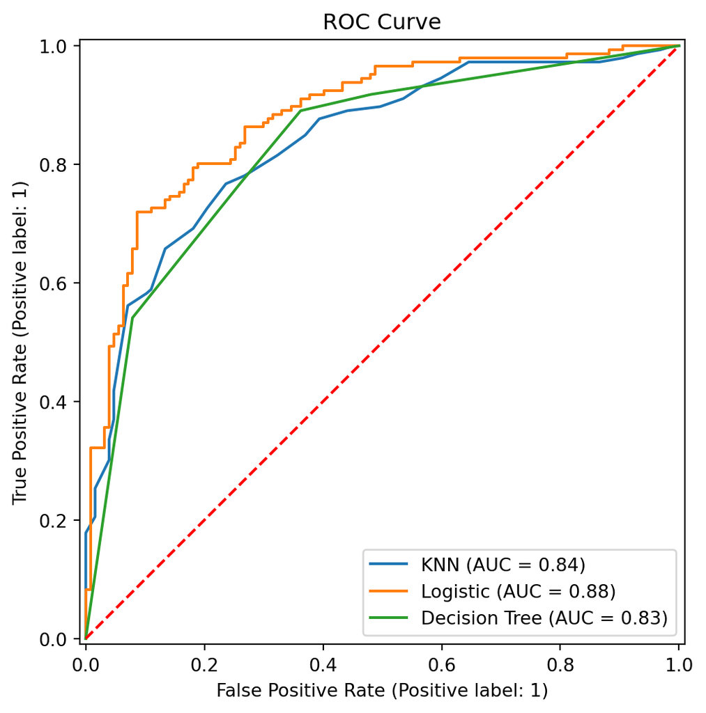

```python
fig, ax = plt.subplots(figsize=(8, 6))
roc_display1 = RocCurveDisplay.from_estimator(knn_pipeline_best, X, y, ax=ax, name="KNN")
roc_display2 = RocCurveDisplay.from_estimator(logisitic_pipeline_best, X, y, ax=ax, name="Logistic")
roc_display3 = RocCurveDisplay.from_estimator(tree_pipeline_best, X, y, ax=ax, name="Decision Tree")
ax.plot([0, 1], [0, 1], color='red', linestyle='--', label='Random classifier')
plt.title('ROC Curve')
plt.show()
```

## Part 2: Metrics

1. Recall Score:

```python
recall_knn=cross_val_score(knn_pipeline_best, X, y, cv=5, scoring='recall')
print("knn recall crossvalidated score:", recall_knn.mean())
recall_logistic=cross_val_score(logisitic_pipeline_best, X, y, cv=5, scoring='recall')
print("logistic recall crossvalidated score:", recall_logistic.mean())
recall_tree=cross_val_score(tree_pipeline_best, X, y, cv=5, scoring='recall')
print("tree recall crossvalidated score:", recall_tree.mean())
```

```
knn recall crossvalidated score: 0.692183908045977
logistic recall crossvalidated score: 0.7951724137931034
tree recall crossvalidated score: 0.7804597701149426
```

2. Precision Score:

```python
precision_knn=cross_val_score(knn_pipeline_best, X, y, cv=5, scoring='precision')
print("knn precision crossvalidated score:", precision_knn.mean())
precision_logistic=cross_val_score(logisitic_pipeline_best, X, y, cv=5, scoring='precision')
print("logistic precision crossvalidated score:", precision_logistic.mean())
precision_tree=cross_val_score(tree_pipeline_best, X, y, cv=5, scoring='precision')
print("tree recall crossvalidated score:", precision_tree.mean())
```

```
knn precision crossvalidated score: 0.7826755852842808
logistic precision crossvalidated score: 0.7906444099378882
tree recall crossvalidated score: 0.7425853361198189
```

3. True negative rate:

```python
def trueneg_score(y_true, y_pred): #used chat gpt for this function and function make_scorer
    tn, fp, fn, tp = confusion_matrix(y_true, y_pred).ravel()
    return tn / (tn + fp)
trueneg_scorer = make_scorer(trueneg_score)

trueneg_knn = cross_val_score(knn_pipeline_best, X, y, cv=5, scoring=trueneg_scorer)
print("knn true negative crossvalidated score:", trueneg_knn.mean())
trueneg_logistic = cross_val_score(logisitic_pipeline_best, X, y, cv=5, scoring=trueneg_scorer)
print("logistic true negative crossvalidated score:", trueneg_logistic.mean())
trueneg_tree = cross_val_score(tree_pipeline_best, X, y, cv=5, scoring=trueneg_scorer)
print("tree true negative crossvalidated score:", trueneg_tree.mean())
```

```
knn true negative crossvalidated score: 0.779076923076923
logistic true negative crossvalidated score: 0.7464615384615385
tree true negative crossvalidated score: 0.684923076923077
```

## Part 3: Discussion

### 1: The hospital faces severe lawsuits if they deem a patient to be low risk, and that patient later experiences a heart attack.

In this situation we want to minimize false negatives the most and make sure that of all the observations that are class A, we have a high score of predicting them as class A. So, we will use the recall scores for model selection. Logistic regression has the highest recall score out of all models with a predicted recall score of 0.795, so we proceed with this model.

### 2: The hospital is overfull, and wants to only use bed space for patients most in need of monitoring due to heart attack risk.

In this situation we want to minimize false positives the most and make sure we have a high percentage of all observations classified as class A are actually class A. So, we will use our precision score as our metric for selection. The logistic regression model has the highest precision score with a precision score of 0.791, so we proceed with this model.

### 3: The hospital is studying root causes of heart attacks, and would like to understand which biological measures are associated with heart attack risk.

For this scenario, we would want to use our logistic regression model due to how this model allows us to view the specific parameters that have an effect on classification. To evaluate this model, we can use the ROC-AUC score as it gives a broad picture of how the model performs in predicting heart risk. For this model and metric we predict a value of 0.88.

### 4: The hospital is training a new batch of doctors, and they would like to compare the diagnoses of these doctors to the predictions given by the algorithm to measure the ability of new doctors to diagnose patients.

For this scenario, we would use our decision tree model. This is due to how it mirrors certain criteria/questions that doctors can use to diagnose patients and put them in categories based on heart risk. To evaluate this model, we can use the ROC-AUC score as it gives a broad picture of how the model performs in predicting heart risk. For this model and metric we predict a value of 0.83.

## 4: Validation

```python
ha_validation = pd.read_csv("https://www.dropbox.com/s/jkwqdiyx6o6oad0/heart_attack_validation.csv?dl=1")
```

```python
ha_validation["sex"]=ha_validation["sex"].astype("str")
ha_validation["cp"]=ha_validation["cp"].astype("str")
ha_validation["restecg"]=ha_validation["restecg"].astype("str")
```

```python
y_test=ha_validation["output"]
X_test=ha_validation.drop(columns="output")
```

```python
knn_preds=knn_pipeline_best.predict(X_test)
logistic_preds=logisitic_pipeline_best.predict(X_test)
tree_preds=tree_pipeline_best.predict(X_test)
```

ROC_AUC scores:

```python
print(roc_auc_score(y_test,knn_preds),
roc_auc_score(y_test,logistic_preds),
roc_auc_score(y_test,tree_preds))
```

```
0.763157894736842 0.7320574162679426 0.7846889952153111
```

The ROC AUC scores are slightly lower with the validation than originally predicted based on the cross validated metrics. However, most of them were very close with the decision tree performing the best (which is not what the cross validated scores suggest). The logistic regression performed the worst when it was predicted to do much better from our cross validated scores, dropping 0.15.

Precision scores:

```python
print(precision_score(y_test,knn_preds),
precision_score(y_test,logistic_preds),
precision_score(y_test,tree_preds))
```

```
1.0 0.8235294117647058 0.8421052631578947
```

The KNN score on the validation data is suspiciously high (value of 1), which suggests that this model, once introduced to the validation data, severly underdiagnoses heart attack risk. The other models also have higher precision scores but it is less of a notable difference.

Recall scores:

```python
print(recall_score(y_test,knn_preds),
recall_score(y_test,logistic_preds),
recall_score(y_test,tree_preds))
```

```
0.5263157894736842 0.7368421052631579 0.8421052631578947
```

As expected, the KNN had a lower recall score than in the cross validation. However, logistic regression performed comporably, and the decision tree performed better than in the cross validation.

Overall, our measures of model success turn out to be approximately correct for the validation data. However, the KNN model performed slightly worse than expected and the decision tree model performed better than expected (decision tree had the highest overall scores on the validation data)

## 5: Cohen’s Kappa

Cohen’s kappa is a metric that compares the accuracy of the model to the accuracy achieved by random chance. A kappa value of zero is equivalent to a random prediction.

```python
kappa_knn = cohen_kappa_score(y_test, knn_preds)
kappa_logistic = cohen_kappa_score(y_test, logistic_preds)
kappa_tree = cohen_kappa_score(y_test, tree_preds)
print(kappa_knn, kappa_logistic, kappa_tree)
```

```
0.44897959183673464 0.4470046082949308 0.569377990430622
```

This metric of model success is best when we are using inbalanced datasets, such as if this data includes many more instances of non heart risk vs heart risk. Also, since this metric accounts for random chance it gives a easy to interpret number that gives a good representation of model performance.

The kappa values are in line with the other metrics used on the validation data, and in this metric the decision tree model performs the best.